# 5 Years Analysis

- 5 years analysis is slightly different with 15 years analysis，but show an identical relationship between the stock price and the unemployment rate and between the stock price and the number of license application

```python
%matplotlib inline
%config InlineBackend.figure_format = 'retina'
import matplotlib.pyplot as plt
import numpy as np

import requests, json

import pandas as pd
import seaborn as sns
sns.set_style("whitegrid", rc={'axes.linewidth': 2.5})
sns.set_context('notebook', font_scale=1.45, rc={"lines.linewidth": 3, "figure.figsize" : (7, 3)})

import pytz
import datetime

from urllib.parse import quote

from scipy import stats
import statsmodels.api as sm
import statsmodels.formula.api as smf
import statsmodels.regression.mixed_linear_model as sm_mlm

from time import sleep
import dask.dataframe as dd
```

## Variations in the Stock Market

- We analyze the stock market trend, and ploted the trend line in the high price and low price.
- We see the high price and low price are sharing the same trend from 2013 to 2017

```python
from googlefinance.client import get_price_data, get_prices_data, get_prices_time_data
get_price_data({"q" : ".DJI", "i" : "86400", "x" : "INDEXDJX", 'p': "5Y"}).head()
```

[output not shown]

```python
finance = get_price_data({"q" : ".DJI", "i" : "86400", "x" : "INDEXDJX", 'p': "5Y"})
```

```
Text(0,0.5,'Stock Price')
```

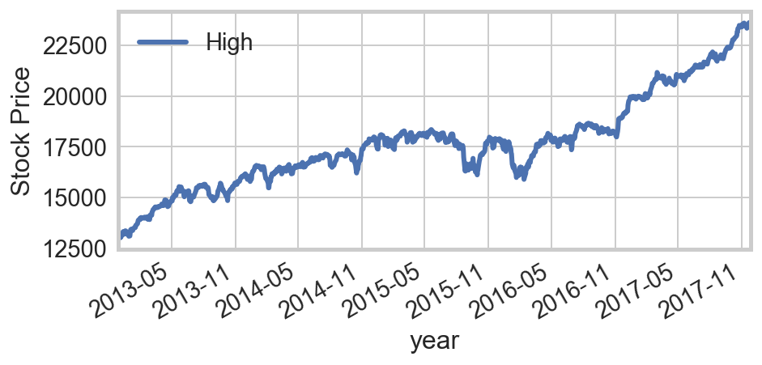

```python
ax = finance.plot(y = "High")
ax.set_xlabel("year")
ax.set_ylabel("Stock Price")
```

```
Text(0,0.5,'Stock Price')
```

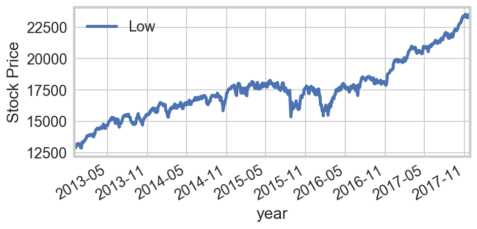

```python
ax = finance.plot(y = "Low")
ax.set_xlabel("year")
ax.set_ylabel("Stock Price")
```

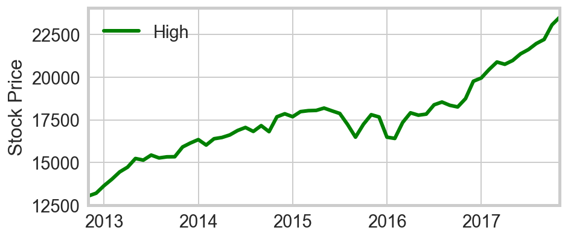

```python
ax = finance.resample("1M").mean().plot(c= "g", y = "High")
ax.set_xlabel("")
ax.set_ylabel("Stock Price");
```

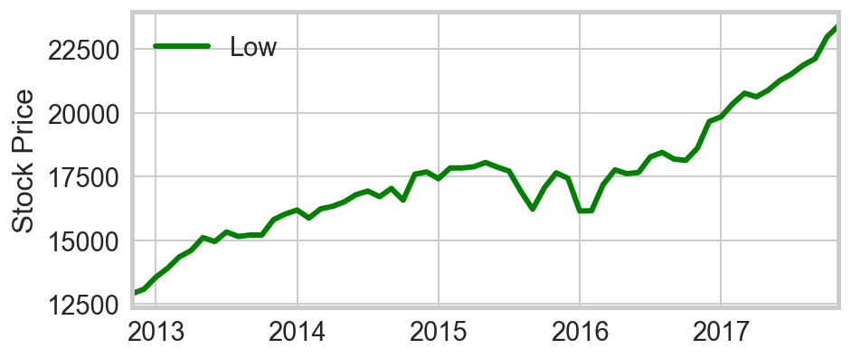

```python
ax = finance.resample("1M").mean().plot(c= "g", y = "Low")
ax.set_xlabel("")
ax.set_ylabel("Stock Price");
```

```python
finance.to_csv('finance_5_year.csv')
```

```python
finance = pd.read_csv ('finance_5_year.csv')
```

```python
finance.head()
```

|  | Date | Open | High | Low | Close | Volume |
| --- | --- | --- | --- | --- | --- | --- |
| 0 | 11/23/2012 | 12833.13 | 13011.45 | 12832.98 | 13009.68 | 61108040 |
| 1 | 11/26/2012 | 13008.30 | 13008.45 | 12900.17 | 12967.37 | 114359887 |
| 2 | 11/27/2012 | 12963.38 | 12980.19 | 12868.26 | 12878.13 | 117895807 |
| 3 | 11/28/2012 | 12875.56 | 12989.10 | 12765.32 | 12985.11 | 130999411 |
| 4 | 11/29/2012 | 12977.35 | 13062.56 | 12961.92 | 13021.82 | 113622832 |

```python
license = pd.read_csv('license.csv')
```

```python
license.head()
```

|  | Unnamed: 0 | BUSINESS ACTIVITY | APPLICATION TYPE | Date |
| --- | --- | --- | --- | --- |
| 0 | 0 | Home Repair Services (Home Occ) | ISSUE | 8/30/2016 |
| 1 | 1 | Organizer of Vendors That Sell for Retail at a... | ISSUE | 8/30/2016 |
| 2 | 2 | Retail Sales of General Merchandise | ISSUE | 8/29/2016 |
| 3 | 3 | Sale of Food Prepared Onsite Without Dining Area | C_LOC | 8/4/2016 |
| 4 | 4 | Provide Waxing Services \| Skincare Services | ISSUE | 8/30/2016 |

```python
unemployment = pd.read_csv('unemployment.csv')
```

```python
fiveyear = unemployment['Date'].str.contains('2017')+unemployment['Date'].str.contains('2016')+unemployment['Date'].str.contains('2015')+unemployment['Date'].str.contains('2014')+unemployment['Date'].str.contains('2013')
```

#### Five Years Unemployment rate

```python
five_year = unemployment[fiveyear]
```

```python
five_year.loc[five_year['Chicago'].idxmax()]
```

```
Date       1/1/2013
Chicago        11.1
Name: 276, dtype: object
```

```python
five_year.loc[five_year['Chicago'].idxmin()]
```

```
Date       3/1/2017
Chicago         4.5
Name: 326, dtype: object
```

```python
daily_count = pd.read_csv('DCOUNT.csv')
```

```python
column = ["Date","COUNT"]
daily_count.columns = column
```

### Merge the License and Finance data

```python
result4 = pd.merge(daily_count, finance, how='right', on=['Date', 'Date'])
```

```python
result4.head(5)
```

|  | Date | COUNT | Open | High | Low | Close | Volume |
| --- | --- | --- | --- | --- | --- | --- | --- |
| 0 | 4/28/2016 | 182.0 | 18023.88 | 18035.73 | 17796.55 | 17830.76 | 100898966 |
| 1 | 4/27/2016 | 174.0 | 17996.14 | 18084.66 | 17920.26 | 18041.55 | 109073815 |
| 2 | 6/19/2014 | 103.0 | 16909.90 | 16923.43 | 16858.88 | 16921.46 | 80221250 |
| 3 | 7/28/2017 | 95.0 | 21787.51 | 21841.18 | 21756.12 | 21830.31 | 285634661 |
| 4 | 6/26/2017 | 91.0 | 21434.68 | 21506.21 | 21381.25 | 21409.55 | 241881336 |

```python
test4 = result4.dropna()
```

```python
test4.head(5)
```

|  | Date | COUNT | Open | High | Low | Close | Volume |
| --- | --- | --- | --- | --- | --- | --- | --- |
| 0 | 4/28/2016 | 182.0 | 18023.88 | 18035.73 | 17796.55 | 17830.76 | 100898966 |
| 1 | 4/27/2016 | 174.0 | 17996.14 | 18084.66 | 17920.26 | 18041.55 | 109073815 |
| 2 | 6/19/2014 | 103.0 | 16909.90 | 16923.43 | 16858.88 | 16921.46 | 80221250 |
| 3 | 7/28/2017 | 95.0 | 21787.51 | 21841.18 | 21756.12 | 21830.31 | 285634661 |
| 4 | 6/26/2017 | 91.0 | 21434.68 | 21506.21 | 21381.25 | 21409.55 | 241881336 |

```python
test4.to_csv('merge_regress1_5year.csv')
```

### Regression analysis on the business license data and stock market (high and low)

##### High price: there is significant relationship

- P-value=0, t-value=3.568, because of this small p-value and large t-value we conclude there is significnat relationship between business license application and high stock market price.
- When the stock market price goes up, we can see the business license application goes up by 0.0007

##### Low price: there is significant relationship

- - P-value=0, t-value=3.666, because of this small p-value and large t-value we conclude there is significnat relationship between business license application and low stock market price.
- When the stock market price goes up, we can see the business license application also goes up by 0.0007

```python
ols = smf.ols(formula = "COUNT ~ High",
              data = test4)
model = ols.fit()
model.summary()
```

OLS Regression Results

| Dep. Variable: | COUNT | R-squared: | 0.010 |
| --- | --- | --- | --- |
| Model: | OLS | Adj. R-squared: | 0.009 |
| Method: | Least Squares | F-statistic: | 12.73 |
| Date: | Thu, 30 Nov 2017 | Prob (F-statistic): | 0.000373 |
| Time: | 23:22:49 | Log-Likelihood: | -5094.5 |
| No. Observations: | 1236 | AIC: | 1.019e+04 |
| Df Residuals: | 1234 | BIC: | 1.020e+04 |
| Df Model: | 1 |  |  |
| Covariance Type: | nonrobust |  |  |

|  | coef | std err | t | P>\|t\| | [0.025 | 0.975] |
| --- | --- | --- | --- | --- | --- | --- |
| Intercept | 22.3705 | 3.364 | 6.650 | 0.000 | 15.771 | 28.970 |
| High | 0.0007 | 0.000 | 3.568 | 0.000 | 0.000 | 0.001 |

| Omnibus: | 671.960 | Durbin-Watson: | 0.039 |
| --- | --- | --- | --- |
| Prob(Omnibus): | 0.000 | Jarque-Bera (JB): | 11168.367 |
| Skew: | 2.136 | Prob(JB): | 0.00 |
| Kurtosis: | 17.093 | Cond. No. | 1.41e+05 |

```python
ols = smf.ols(formula = "COUNT ~ Low",
              data = test4)
model = ols.fit()
model.summary()
```

OLS Regression Results

| Dep. Variable: | COUNT | R-squared: | 0.011 |
| --- | --- | --- | --- |
| Model: | OLS | Adj. R-squared: | 0.010 |
| Method: | Least Squares | F-statistic: | 13.44 |
| Date: | Thu, 30 Nov 2017 | Prob (F-statistic): | 0.000256 |
| Time: | 23:23:27 | Log-Likelihood: | -5094.1 |
| No. Observations: | 1236 | AIC: | 1.019e+04 |
| Df Residuals: | 1234 | BIC: | 1.020e+04 |
| Df Model: | 1 |  |  |
| Covariance Type: | nonrobust |  |  |

|  | coef | std err | t | P>\|t\| | [0.025 | 0.975] |
| --- | --- | --- | --- | --- | --- | --- |
| Intercept | 22.2264 | 3.314 | 6.706 | 0.000 | 15.724 | 28.729 |
| Low | 0.0007 | 0.000 | 3.666 | 0.000 | 0.000 | 0.001 |

| Omnibus: | 672.207 | Durbin-Watson: | 0.040 |
| --- | --- | --- | --- |
| Prob(Omnibus): | 0.000 | Jarque-Bera (JB): | 11207.250 |
| Skew: | 2.136 | Prob(JB): | 0.00 |
| Kurtosis: | 17.120 | Cond. No. | 1.38e+05 |

- We can tell there is positive relationship between business license application and high stock market price
- As the stock market price goes up, there is more business license application. Becuase the coefficient is small, the relationship is not obvious

[figure not shown]

```python
m = pd.Series(name = "COUNT", data = model.resid + test4["High"] * model.params["High"])
sns.regplot(x = test4["High"], y = m, lowess = True,
            scatter_kws = {"alpha" : 0.1, "color" : "red"}, line_kws = {"color" : "grey"},);
```

#### Same as we see from the regression above, from this graph, we also observe there is significant relationship between business license application and low stock market price, as the regression line points to up.

- We can tell there is positive relationship between business license application and low stock market price
- As the stock market price goes up, there is more business license application, however as the coefficient is small, the trend is not obvious

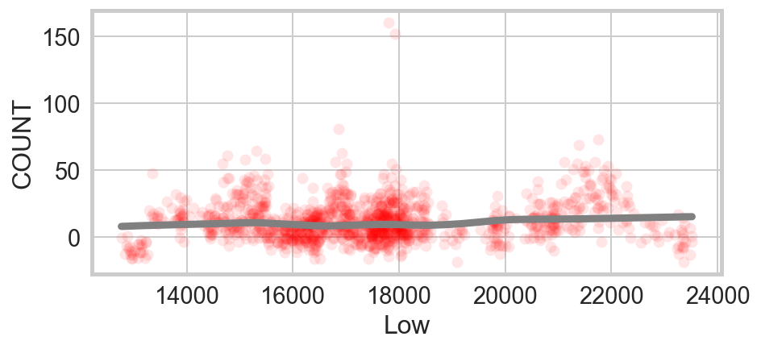

```python
n = pd.Series(name = "COUNT", data = model.resid + test4["Low"] * model.params["Low"])
sns.regplot(x = test4["Low"], y = n, lowess = True,
            scatter_kws = {"alpha" : 0.1, "color" : "red"}, line_kws = {"color" : "grey"});
```

### We use Seaborn to double check the result, and we find same regression relationship as we found before

[figure not shown]

```python
f = pd.Series(name = "Component + Residual", data = model.resid + test4["High"] * model.params["High"])
ax = sns.regplot(x = test4["High"], y = f, scatter = True, fit_reg = False,
            scatter_kws = {"alpha" : 0.1, "color" : "red"})
sns.regplot(x = test4["High"], y = f, scatter = False,
            lowess = False, robust = True, label = "Linear",
            scatter_kws = {"alpha" : 0.1, "color" : "red"}, line_kws = {"color" : "yellow", "linewidth" : 2})
sns.regplot(x = test4["High"], y = f, scatter = False,
            lowess = True, label = "Lowess",
            scatter_kws = {"alpha" : 0}, line_kws = {"color" : "grey", "linewidth" : 2}, ax = ax);

ax.legend()
```

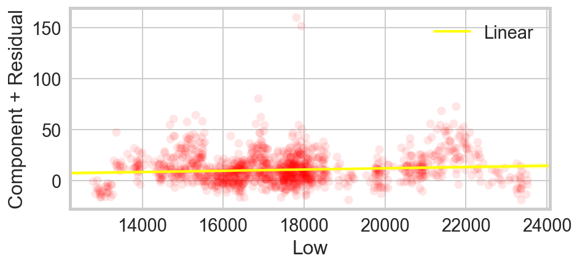

```python
f = pd.Series(name = "Component + Residual", data = model.resid + test4["Low"] * model.params["Low"])
ax2 = sns.regplot(x = test4["Low"], y = f, scatter = True, fit_reg = False,
            scatter_kws = {"alpha" : 0.1, "color" : "red"})
sns.regplot(x = test4["Low"], y = f, scatter = False,
            lowess = False, robust = True, label = "Linear",
            scatter_kws = {"alpha" : 0.1, "color" : "red"}, line_kws = {"color" : "yellow", "linewidth" : 2})
sns.regplot(x = test4["Low"], y = f, scatter = False,
            lowess = True, label = "Lowess",
            scatter_kws = {"alpha" : 0}, line_kws = {"color" : "grey", "linewidth" : 2}, ax = ax);

ax2.legend()
```

```python
result5 = pd.merge(unemployment, test4, how='right', on=['Date', 'Date'])
```

```python
result5.head()
```

|  | Date | Chicago | COUNT | Open | High | Low | Close | Volume |
| --- | --- | --- | --- | --- | --- | --- | --- | --- |
| 0 | 2/1/2013 | 10.6 | 40.0 | 13860.58 | 14019.78 | 13860.58 | 14009.79 | 128420423 |
| 1 | 3/1/2013 | 9.9 | 40.0 | 14054.49 | 14107.09 | 13937.60 | 14089.66 | 125915928 |
| 2 | 4/1/2013 | 9.7 | 51.0 | 14578.54 | 14605.72 | 14531.48 | 14572.85 | 91396856 |
| 3 | 5/1/2013 | 10.0 | 45.0 | 14839.80 | 14839.80 | 14687.05 | 14700.95 | 112619408 |
| 4 | 7/1/2013 | 10.5 | 33.0 | 14911.60 | 15083.28 | 14911.60 | 14974.96 | 120572441 |

```python
test5 = result5.dropna()
```

```python
test5.head()
```

|  | Date | Chicago | COUNT | Open | High | Low | Close | Volume |
| --- | --- | --- | --- | --- | --- | --- | --- | --- |
| 0 | 2/1/2013 | 10.6 | 40.0 | 13860.58 | 14019.78 | 13860.58 | 14009.79 | 128420423 |
| 1 | 3/1/2013 | 9.9 | 40.0 | 14054.49 | 14107.09 | 13937.60 | 14089.66 | 125915928 |
| 2 | 4/1/2013 | 9.7 | 51.0 | 14578.54 | 14605.72 | 14531.48 | 14572.85 | 91396856 |
| 3 | 5/1/2013 | 10.0 | 45.0 | 14839.80 | 14839.80 | 14687.05 | 14700.95 | 112619408 |
| 4 | 7/1/2013 | 10.5 | 33.0 | 14911.60 | 15083.28 | 14911.60 | 14974.96 | 120572441 |

```python
test5.to_csv('merge_regress2_5year.csv')
```

#### We run regression on the unemployment rate and stock market price, and found there is significant relationship

##### High stock market price: negative relationship

- while holding other factors fixed, we see the p-value for the high price is 0.00, also we see the t-value is -10.809. So we conclude there is significant relationship between unemployment rate and high stock market price, because of the small P-value and large t-value
- when the high stock market price goes up, the unemployment rate goes down by 0.0008

##### Low stock market price: negative relationship

- while holding other factors fixed, we see the p-value for the low price is 0.00, also we see the t-value is -10.025. So we conclude there is significant relationship between unemployment rate and low stock market price, because of the small P-value and large t-value
- when the low stock market price goes down, the unemployment rate goes up by 0.0008

```python
ols = smf.ols(formula = "Chicago ~ High",
              data = test5)
model = ols.fit()
model.summary()
```

OLS Regression Results

| Dep. Variable: | Chicago | R-squared: | 0.785 |
| --- | --- | --- | --- |
| Model: | OLS | Adj. R-squared: | 0.778 |
| Method: | Least Squares | F-statistic: | 116.8 |
| Date: | Thu, 30 Nov 2017 | Prob (F-statistic): | 3.26e-12 |
| Time: | 23:44:46 | Log-Likelihood: | -39.971 |
| No. Observations: | 34 | AIC: | 83.94 |
| Df Residuals: | 32 | BIC: | 86.99 |
| Df Model: | 1 |  |  |
| Covariance Type: | nonrobust |  |  |

|  | coef | std err | t | P>\|t\| | [0.025 | 0.975] |
| --- | --- | --- | --- | --- | --- | --- |
| Intercept | 21.4775 | 1.317 | 16.305 | 0.000 | 18.794 | 24.161 |
| High | -0.0008 | 7.58e-05 | -10.809 | 0.000 | -0.001 | -0.001 |

| Omnibus: | 2.998 | Durbin-Watson: | 0.663 |
| --- | --- | --- | --- |
| Prob(Omnibus): | 0.223 | Jarque-Bera (JB): | 1.715 |
| Skew: | -0.413 | Prob(JB): | 0.424 |
| Kurtosis: | 3.726 | Cond. No. | 1.65e+05 |

```python
ols = smf.ols(formula = "Chicago ~ Low",
              data = test5)
model = ols.fit()
model.summary()
```

OLS Regression Results

| Dep. Variable: | Chicago | R-squared: | 0.759 |
| --- | --- | --- | --- |
| Model: | OLS | Adj. R-squared: | 0.751 |
| Method: | Least Squares | F-statistic: | 100.5 |
| Date: | Thu, 30 Nov 2017 | Prob (F-statistic): | 2.13e-11 |
| Time: | 23:52:19 | Log-Likelihood: | -41.947 |
| No. Observations: | 34 | AIC: | 87.89 |
| Df Residuals: | 32 | BIC: | 90.95 |
| Df Model: | 1 |  |  |
| Covariance Type: | nonrobust |  |  |

|  | coef | std err | t | P>\|t\| | [0.025 | 0.975] |
| --- | --- | --- | --- | --- | --- | --- |
| Intercept | 21.0278 | 1.375 | 15.288 | 0.000 | 18.226 | 23.829 |
| Low | -0.0008 | 7.99e-05 | -10.025 | 0.000 | -0.001 | -0.001 |

| Omnibus: | 4.690 | Durbin-Watson: | 0.663 |
| --- | --- | --- | --- |
| Prob(Omnibus): | 0.096 | Jarque-Bera (JB): | 3.199 |
| Skew: | -0.584 | Prob(JB): | 0.202 |
| Kurtosis: | 3.945 | Cond. No. | 1.61e+05 |

#### We run regression on unemployment rate and number of license application: No significance relationship

```python
ols = smf.ols(formula = "Chicago ~ COUNT",
              data = test5)
model = ols.fit()
model.summary()
```

OLS Regression Results

| Dep. Variable: | Chicago | R-squared: | 0.008 |
| --- | --- | --- | --- |
| Model: | OLS | Adj. R-squared: | -0.023 |
| Method: | Least Squares | F-statistic: | 0.2685 |
| Date: | Thu, 30 Nov 2017 | Prob (F-statistic): | 0.608 |
| Time: | 23:41:05 | Log-Likelihood: | -65.960 |
| No. Observations: | 34 | AIC: | 135.9 |
| Df Residuals: | 32 | BIC: | 139.0 |
| Df Model: | 1 |  |  |
| Covariance Type: | nonrobust |  |  |

|  | coef | std err | t | P>\|t\| | [0.025 | 0.975] |
| --- | --- | --- | --- | --- | --- | --- |
| Intercept | 6.8605 | 0.931 | 7.368 | 0.000 | 4.964 | 8.757 |
| COUNT | 0.0133 | 0.026 | 0.518 | 0.608 | -0.039 | 0.066 |

| Omnibus: | 2.949 | Durbin-Watson: | 0.096 |
| --- | --- | --- | --- |
| Prob(Omnibus): | 0.229 | Jarque-Bera (JB): | 2.580 |
| Skew: | 0.585 | Prob(JB): | 0.275 |
| Kurtosis: | 2.327 | Cond. No. | 113. |

#### We hold fix the count, the relationship is still strong for high price and unemployment rate

```python
ols = smf.ols(formula = "Chicago ~ High + COUNT",
              data = test5)
model = ols.fit()
model.summary()
```

OLS Regression Results

| Dep. Variable: | Chicago | R-squared: | 0.805 |
| --- | --- | --- | --- |
| Model: | OLS | Adj. R-squared: | 0.792 |
| Method: | Least Squares | F-statistic: | 64.01 |
| Date: | Thu, 30 Nov 2017 | Prob (F-statistic): | 9.86e-12 |
| Time: | 23:29:05 | Log-Likelihood: | -38.307 |
| No. Observations: | 34 | AIC: | 82.61 |
| Df Residuals: | 31 | BIC: | 87.19 |
| Df Model: | 2 |  |  |
| Covariance Type: | nonrobust |  |  |

|  | coef | std err | t | P>\|t\| | [0.025 | 0.975] |
| --- | --- | --- | --- | --- | --- | --- |
| Intercept | 20.8951 | 1.316 | 15.883 | 0.000 | 18.212 | 23.578 |
| High | -0.0008 | 7.34e-05 | -11.256 | 0.000 | -0.001 | -0.001 |
| COUNT | 0.0207 | 0.012 | 1.785 | 0.084 | -0.003 | 0.044 |

| Omnibus: | 1.107 | Durbin-Watson: | 0.709 |
| --- | --- | --- | --- |
| Prob(Omnibus): | 0.575 | Jarque-Bera (JB): | 0.330 |
| Skew: | -0.151 | Prob(JB): | 0.848 |
| Kurtosis: | 3.377 | Cond. No. | 1.71e+05 |

#### We plot the unemployment and number of license application and comfirmed there is no significant relationship between these two data

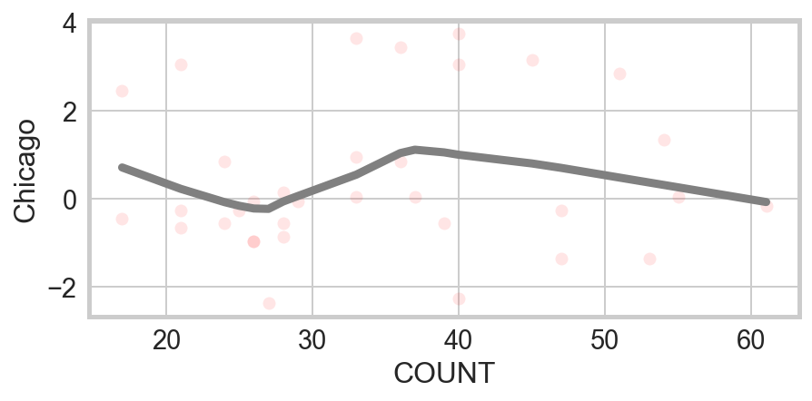

```python
m = pd.Series(name = "Chicago", data = model.resid + test5["COUNT"] * model.params["COUNT"])
sns.regplot(x = test5["COUNT"], y = m, lowess = True,
            scatter_kws = {"alpha" : 0.1, "color" : "red"}, line_kws = {"color" : "grey"});
```

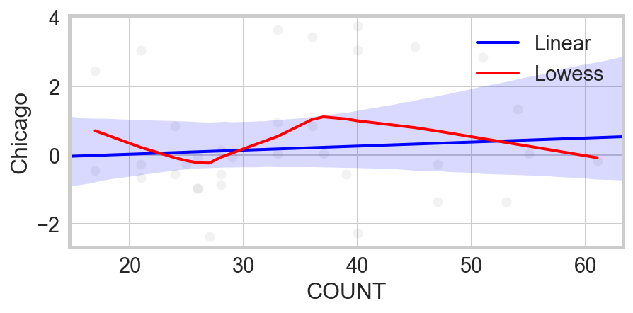

```python
f = pd.Series(name = "Chicago", data = model.resid + test5["COUNT"] * model.params["COUNT"])
ax = sns.regplot(x = test5["COUNT"], y = f, scatter = True, fit_reg = False,
            scatter_kws = {"alpha" : 0.1, "color" : "grey"})
sns.regplot(x = test5["COUNT"], y = f, scatter = False,
            lowess = False, robust = True, label = "Linear",
            scatter_kws = {"alpha" : 0.1, "color" : "grey"}, line_kws = {"color" : "blue", "linewidth" : 2})
sns.regplot(x = test5["COUNT"], y = f, scatter = False,
            lowess = True, label = "Lowess",
            scatter_kws = {"alpha" : 0}, line_kws = {"color" : "red", "linewidth" : 2}, ax = ax);

ax.legend()
```

#### We also plot the trend line of high, low and unemployment rate with pd and check with seaborn

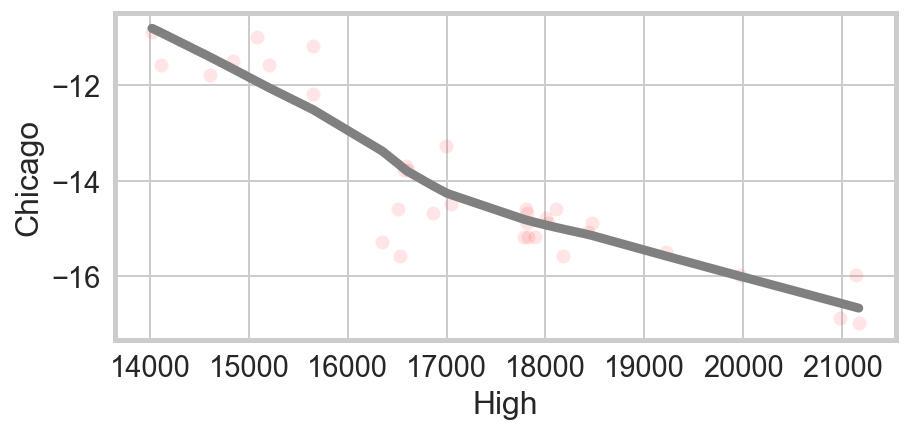

```python
m = pd.Series(name = "Chicago", data = model.resid + test5["High"] * model.params["High"])
sns.regplot(x = test5["High"], y = m, lowess = True,
            scatter_kws = {"alpha" : 0.1, "color" : "red"}, line_kws = {"color" : "grey"});
```

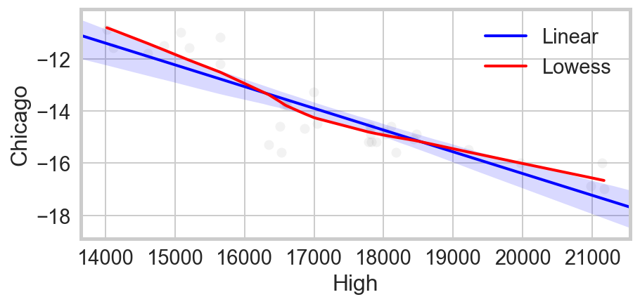

```python
f = pd.Series(name = "Chicago", data = model.resid + test5["High"] * model.params["High"])
ax = sns.regplot(x = test5["High"], y = f, scatter = True, fit_reg = False,
            scatter_kws = {"alpha" : 0.1, "color" : "grey"})
sns.regplot(x = test5["High"], y = f, scatter = False,
            lowess = False, robust = True, label = "Linear",
            scatter_kws = {"alpha" : 0.1, "color" : "grey"}, line_kws = {"color" : "blue", "linewidth" : 2})
sns.regplot(x = test5["High"], y = f, scatter = False,
            lowess = True, label = "Lowess",
            scatter_kws = {"alpha" : 0}, line_kws = {"color" : "red", "linewidth" : 2}, ax = ax);
ax.legend()
```

[figure not shown]

```python
m = pd.Series(name = "Chicago", data = model.resid + test5["Low"] * model.params["Low"])
sns.regplot(x = test5["Low"], y = m, lowess = True,
            scatter_kws = {"alpha" : 0.1, "color" : "red"}, line_kws = {"color" : "grey"});
```

[figure not shown]

```python
f = pd.Series(name = "Chicago", data = model.resid + test5["Low"] * model.params["Low"])
ax = sns.regplot(x = test5["Low"], y = f, scatter = True, fit_reg = False,
            scatter_kws = {"alpha" : 0.1, "color" : "grey"})
sns.regplot(x = test5["Low"], y = f, scatter = False,
            lowess = False, robust = True, label = "Linear",
            scatter_kws = {"alpha" : 0.1, "color" : "grey"}, line_kws = {"color" : "blue", "linewidth" : 2})
sns.regplot(x = test5["Low"], y = f, scatter = False,
            lowess = True, label = "Lowess",
            scatter_kws = {"alpha" : 0}, line_kws = {"color" : "red", "linewidth" : 2}, ax = ax);
ax.legend()
```